# Survival Analysis- Predicting Time-to-Event

Pei-Chien Tsai

2025-10-22

Introduction

A survival analysis helps us to answer questions like:

- Does a new therapy extend the time until cancer recurs? What patient characteristics are associated with longer survival?
- Can we predict a specific patient’s probability of surviving for 5 years?

The major differences between a logistic regression model and a survival model is: we’re no longer predicting if an event happens (Yes/No), but **when** it happens.

In logistic regression, we were interested in finding the associations between the risk factors and the outcome, for example, the presence or absence of disease.

In survival analysis, the focus is not only on finding the associations but also about “time” to the event.

The response is often referred to as failure time, survival time, or event time.

For examples:

- Time until cancer/disease death after treatment intervention.
- Time until disease occurrence (e.g., AIDS event for HIV patients).
- Time until disease/tumor recurrence.

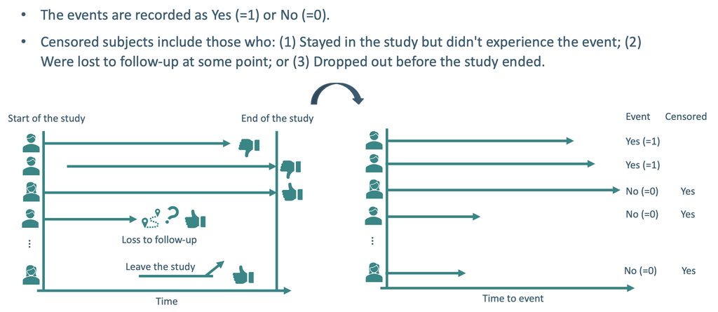

Concept of survival analysis

The data we will use today is called gbsg from survival package.

Our workflow today will mirror the real process of data analysis:

1. Understand the Data: What do our variables mean? What are their data types?
2. Form Hypotheses: Based on clinical knowledge, what do we expect to find?
3. Clean & Prepare: Correct data types and check for obvious issues.
4. Analyze: Build and refine our statistical models.
5. Interpret & Predict: Visualize our results and use the model to make predictions.

### 1. Understand the dataset

```r
library(survival)   # The core package for survival analysis
library(dplyr)      # For data manipulation
library(survminer)  # For beautiful survival plots, including forest plots
library(ggplot2)    # For general plotting
library(PerformanceAnalytics) # For correlation matrix

# The gbsg dataset is in the `survival` package
data(gbsg)

# Look at the structure
str(gbsg)
```

```
## 'data.frame':    686 obs. of  11 variables:
##  $ pid    : int  132 1575 1140 769 130 1642 475 973 569 1180 ...
##  $ age    : int  49 55 56 45 65 48 48 37 67 45 ...
##  $ meno   : int  0 1 1 0 1 0 0 0 1 0 ...
##  $ size   : int  18 20 40 25 30 52 21 20 20 30 ...
##  $ grade  : int  2 3 3 3 2 2 3 2 2 2 ...
##  $ nodes  : int  2 16 3 1 5 11 8 9 1 1 ...
##  $ pgr    : int  0 0 0 0 0 0 0 0 0 0 ...
##  $ er     : int  0 0 0 4 36 0 0 0 0 0 ...
##  $ hormon : int  0 0 0 0 1 0 0 1 1 0 ...
##  $ rfstime: int  1838 403 1603 177 1855 842 293 42 564 1093 ...
##  $ status : int  0 1 0 0 0 1 1 0 1 1 ...
```

Key Variables:

Major outcome:

- rfstime: Recurrence-free survival time in days (our time variable).
- status: Event indicator (0 = alive/censored, 1 = recurrence or death) (our event variable).

Predictors/Risk factors:

- meno: menopausal status (0= premenopausal, 1= postmenopausal)
- size: tumor size, mm
- grade: tumor grade (1-3)
- nodes: number of positive lymph nodes
- pgr: progesterone receptors (fmol/l)
- er: estrogen receptors (fmol/l)
- hormon: hormonal therapy (0=no, 1=yes)

### 2. Data Cleaning: Spotting and Correcting Data Types

From the structure (str) output, we can see that key categorical variables are stored as integers (int). This will confuse our models. We need to convert them to factors and give them meaningful labels.

```r
# Let's clean the data using dplyr
gbsg_clean <- gbsg %>%
  mutate(
    # Convert menopausal status to a factor
    meno = factor(meno, levels = c(0, 1), labels = c("Premenopausal", "Postmenopausal")),

    # Convert tumor grade to an ordered factor
    grade = factor(grade, ordered = TRUE, levels = c("1", "2", "3")),

    # Convert hormonal therapy to a factor
    hormon = factor(hormon, levels = c(0, 1), labels = c("No", "Yes")),

    # Also convert the event status to a factor for clarity in plots
    status = factor(status, levels = c(0, 1), labels = c("Censored", "Event")))

# Let's check the dataset again
str(gbsg_clean)
```

```
## 'data.frame':    686 obs. of  11 variables:
##  $ pid    : int  132 1575 1140 769 130 1642 475 973 569 1180 ...
##  $ age    : int  49 55 56 45 65 48 48 37 67 45 ...
##  $ meno   : Factor w/ 2 levels "Premenopausal",..: 1 2 2 1 2 1 1 1 2 1 ...
##  $ size   : int  18 20 40 25 30 52 21 20 20 30 ...
##  $ grade  : Ord.factor w/ 3 levels "1"<"2"<"3": 2 3 3 3 2 2 3 2 2 2 ...
##  $ nodes  : int  2 16 3 1 5 11 8 9 1 1 ...
##  $ pgr    : int  0 0 0 0 0 0 0 0 0 0 ...
##  $ er     : int  0 0 0 4 36 0 0 0 0 0 ...
##  $ hormon : Factor w/ 2 levels "No","Yes": 1 1 1 1 2 1 1 2 2 1 ...
##  $ rfstime: int  1838 403 1603 177 1855 842 293 42 564 1093 ...
##  $ status : Factor w/ 2 levels "Censored","Event": 1 2 1 1 1 2 2 1 2 2 ...
```

### 3. Understanding Variables & Forming Hypotheses

Before we model, let’s think about what we expect to see. This is a critical step to ensure our results make sense.

- `meno`: Postmenopausal women are generally older, which could be a risk factor.
- `size`: Larger tumor size will be associated with a higher risk of recurrence (Higher Hazard Ratio).
- `grade`: Tumor grade is a measure of cell abnormality. Higher grade (3 vs 1) will be associated with a much higher risk.
- `nodes`: The number of positive lymph nodes is a strong indicator of cancer spread. More nodes will be strongly associated with a higher risk.
- `pgr` & `er`: Progesterone and estrogen receptors are markers of hormone sensitivity. High levels often mean the cancer can be treated with hormonal therapy, which is a good thing. Higher pgr/er levels will be associated with a lower risk (Hazard Ratio < 1).
- `hormon`: Receiving hormonal therapy should be associated with a lower risk.

Let’s check summary statistics to look for outliers.

```r
summary(gbsg_clean)
```

```
##       pid              age                    meno          size        grade
##  Min.   :   1.0   Min.   :21.00   Premenopausal :290   Min.   :  3.00   1: 81
##  1st Qu.: 580.8   1st Qu.:46.00   Postmenopausal:396   1st Qu.: 20.00   2:444
##  Median :1015.5   Median :53.00                        Median : 25.00   3:161
##  Mean   : 966.1   Mean   :53.05                        Mean   : 29.33
##  3rd Qu.:1340.5   3rd Qu.:61.00                        3rd Qu.: 35.00
##  Max.   :1819.0   Max.   :80.00                        Max.   :120.00
##      nodes            pgr               er          hormon       rfstime
##  Min.   : 1.00   Min.   :   0.0   Min.   :   0.00   No :440   Min.   :   8.0
##  1st Qu.: 1.00   1st Qu.:   7.0   1st Qu.:   8.00   Yes:246   1st Qu.: 567.8
##  Median : 3.00   Median :  32.5   Median :  36.00             Median :1084.0
##  Mean   : 5.01   Mean   : 110.0   Mean   :  96.25             Mean   :1124.5
##  3rd Qu.: 7.00   3rd Qu.: 131.8   3rd Qu.: 114.00             3rd Qu.:1684.8
##  Max.   :51.00   Max.   :2380.0   Max.   :1144.00             Max.   :2659.0
##       status
##  Censored:387
##  Event   :299
##
##
##
##
```

### 4. Performing exploratory data analysis

Now, let’s first perform the summary statistics for our varaibles

```r
library(gtsummary)

table1 <- gbsg_clean %>%
  # 1. Select all columns EXCEPT for pid
  select(-pid) %>%

  # 2. This is the main function to create the table
  tbl_summary(
    # --- Column Settings ---
    by = status,  # This tells gtsummary to create columns for each level of 'status'

    # --- Statistics Formatting ---
    statistic = list(
      all_continuous() ~ "{mean} ({sd})",  # For continuous vars: show Mean (SD)
      all_categorical() ~ "{n} ({p}%)"      # For categorical vars: show N (%)
    )
    # The tbl_summary() function ends here
  ) %>% # <--- THIS IS THE FIX: A pipe to add the next step

  # 3. Now we ADD the p-value column to the table we just created
  add_p()

# 4. Print the final table
table1
```

| **Characteristic** | **Censored** N = 387<sup>1</sup> | **Event** N = 299<sup>1</sup> | **p-value**<sup>2</sup> |
| --- | --- | --- | --- |
| age | 53 (10) | 53 (11) | 0.7 |
| meno |  |  | 0.2 |
| Premenopausal | 171 (44%) | 119 (40%) |  |
| Postmenopausal | 216 (56%) | 180 (60%) |  |
| size | 28 (13) | 31 (16) | 0.002 |
| grade |  |  | <0.001 |
| 1 | 63 (16%) | 18 (6.0%) |  |
| 2 | 242 (63%) | 202 (68%) |  |
| 3 | 82 (21%) | 79 (26%) |  |
| nodes | 4 (5) | 7 (6) | <0.001 |
| pgr | 140 (243) | 71 (122) | <0.001 |
| er | 105 (153) | 86 (153) | 0.001 |
| hormon | 152 (39%) | 94 (31%) | 0.034 |
| rfstime | 1,377 (627) | 798 (501) | <0.001 |

<sup>1</sup> Mean (SD); n (%)  
<sup>2</sup> Wilcoxon rank sum test; Pearson’s Chi-squared test

```r
# From this table, we can see that for those who has the event (recurrence), they tend to have larger tumor size, with higher tumor grade, more nodes, lower pgr/er/hormone levels. This result seems to fit our expectation.
```

Furthermore, we also check the associations between predictors before building the survival model.

From the previous lectures, we know:

- Continous vs. Continuous: Pearson’s correlation
- Continuous vs. Dichotomous: Independent T-test
- Continous vs. Polytomous (>2): ANOVA
- Categorical vs. Categorical: Chi-square test

```r
# 1. Relationship between Continuous Predictors: Correlation

# Question: Are the two hormone receptor levels, pgr and er, related to each other?
cor_test_receptors <- cor.test(gbsg_clean$pgr, gbsg_clean$er)
cor_test_receptors
```

```
##
##  Pearson's product-moment correlation
##
## data:  gbsg_clean$pgr and gbsg_clean$er
## t = 11.164, df = 684, p-value < 2.2e-16
## alternative hypothesis: true correlation is not equal to 0
## 95 percent confidence interval:
##  0.3273665 0.4541114
## sample estimates:
##       cor
## 0.3926013
```

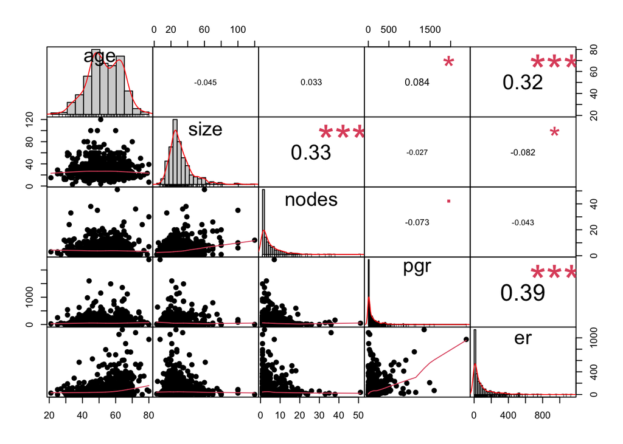

```r
# or we can do an overal check
chart.Correlation(gbsg_clean[,c(2,4,6:8)], histogram = TRUE, pch = 19)
```

```r
# 2. Relationship between Continuous and Categorical (2 levels): T-test

# Question: Do postmenopausal women have, on average, a different tumor size than premenopausal women?

var.test(size ~ meno,data=gbsg_clean) #sig, suggest variances are not equal
```

```
##
##  F test to compare two variances
##
## data:  size by meno
## F = 1.2995, num df = 289, denom df = 395, p-value = 0.01595
## alternative hypothesis: true ratio of variances is not equal to 1
## 95 percent confidence interval:
##  1.050103 1.614055
## sample estimates:
## ratio of variances
##           1.299533
```

```r
ttest_size_meno <- t.test(size ~ meno, data = gbsg_clean,var.equal=F)
ttest_size_meno
```

```
##
##  Welch Two Sample t-test
##
## data:  size by meno
## t = 1.0782, df = 573.29, p-value = 0.2814
## alternative hypothesis: true difference in means between group Premenopausal and group Postmenopausal is not equal to 0
## 95 percent confidence interval:
##  -0.9986919  3.4294477
## sample estimates:
##  mean in group Premenopausal mean in group Postmenopausal
##                     30.03103                     28.81566
```

```r
# Nope, postmenopausal women don't have a different tumor size than premenopausal women.
# Even, postmenopausal women have a smaller mean tumor size (28.82 mm) compared to premenopausal women (30.03 mm).

# 3. Relationship between Continuous and Categorical (>2 levels): ANOVA

# Question: Does the number of positive lymph nodes differ across the three tumor grades?

# Perform ANOVA
anova_nodes_grade <- aov(nodes ~ grade, data = gbsg_clean)
summary(anova_nodes_grade)
```

```
##              Df Sum Sq Mean Sq F value   Pr(>F)
## grade         2    437  218.62   7.429 0.000643 ***
## Residuals   683  20100   29.43
## ---
## Signif. codes:  0 '***' 0.001 '**' 0.01 '*' 0.05 '.' 0.1 ' ' 1
```

```r
TukeyHSD(anova_nodes_grade)
```

```
##   Tukey multiple comparisons of means
##     95% family-wise confidence level
##
## Fit: aov(formula = nodes ~ grade, data = gbsg_clean)
##
## $grade
##         diff         lwr      upr     p adj
## 2-1 1.679930  0.14042299 3.219437 0.0285082
## 3-1 2.827697  1.09194305 4.563451 0.0004166
## 3-2 1.147767 -0.02445302 2.319988 0.0564866
```

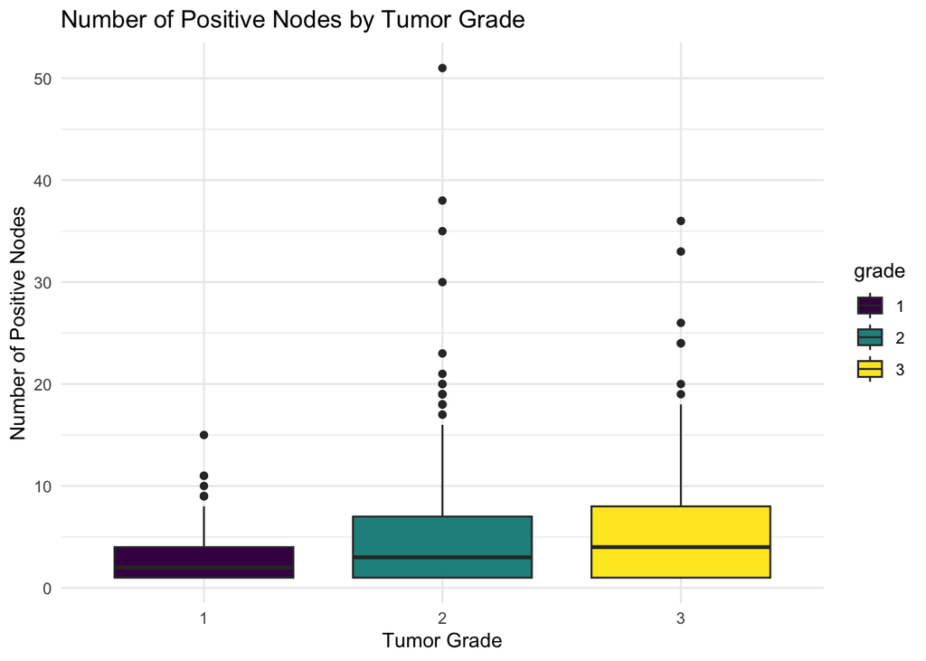

```r
# Here ANOVA test shows at least one of the grade group has significantly different nodes number.
# Using the Tukey's posthoc test, we can see the order of nodes number is grade 3 > 2 > 1.
# Both grade 2 vs. grade 1, and grade 3 vs. grade 1 show a significant differences of nodes number.

# A boxplot is the best way to visualize this!
ggplot(gbsg_clean, aes(x = grade, y = nodes, fill = grade)) +
  geom_boxplot() +
  labs(title = "Number of Positive Nodes by Tumor Grade",
       x = "Tumor Grade", y = "Number of Positive Nodes") +
  theme_minimal()
```

```r
# 4. Relationship between Categorical Predictors: Chi-squared Test

# Question: Is there an association between menopausal status and tumor grade?

# Create a contingency table
contingency_table_meno_grade <- table(gbsg_clean$meno, gbsg_clean$grade)
print(contingency_table_meno_grade)
```

```
##
##                    1   2   3
##   Premenopausal   33 183  74
##   Postmenopausal  48 261  87
```

```r
# Perform the Chi-squared test
chisq_test_meno_grade <- chisq.test(contingency_table_meno_grade)
print(chisq_test_meno_grade)
```

```
##
##  Pearson's Chi-squared test
##
## data:  contingency_table_meno_grade
## X-squared = 1.1793, df = 2, p-value = 0.5545
```

```r
# The result shows there is no statistical association between grade and menopausal status.

# You can use the same approaches to examine the associations between your variables.
```

### 5. Performing the Survival Analysis

Step A: Univariate Analysis (Simple Models)

### Quantifying risk: continous variables

First, let’s test each predictor one by one to see its individual association with survival. We start by creating our “Survival Object”, and use Cox Proportional Hzards model for the analysis.

The key output from a Cox model is the Hazard Ratio (HR).

- HR = 1: The predictor has no effect on the hazard of the event.
- HR > 1: The predictor is a risk factor. An increase in the predictor is associated with an increased hazard of the event.
- HR < 1: The predictor is a protective factor. An increase in the predictor is associated with a decreased hazard of the event.

```r
# Create the Survival object
# This combines the time-to-event (rfstime) and the event status (status)
surv_obj <- Surv(time = gbsg_clean$rfstime, event = gbsg_clean$status == "Event")
head(surv_obj)
```

```
## [1] 1838+  403  1603+  177+ 1855+  842
```

```r
summary(coxph(surv_obj ~ age, data = gbsg_clean))
```

```
## Call:
## coxph(formula = surv_obj ~ age, data = gbsg_clean)
##
##   n= 686, number of events= 299
##
##          coef exp(coef)  se(coef)      z Pr(>|z|)
## age -0.004485  0.995525  0.005887 -0.762    0.446
##
##     exp(coef) exp(-coef) lower .95 upper .95
## age    0.9955      1.004    0.9841     1.007
##
## Concordance= 0.519  (se = 0.018 )
## Likelihood ratio test= 0.58  on 1 df,   p=0.4
## Wald test            = 0.58  on 1 df,   p=0.4
## Score (logrank) test = 0.58  on 1 df,   p=0.4
```

```r
summary(coxph(surv_obj ~ size, data = gbsg_clean))
```

```
## Call:
## coxph(formula = surv_obj ~ size, data = gbsg_clean)
##
##   n= 686, number of events= 299
##
##          coef exp(coef) se(coef)     z Pr(>|z|)
## size 0.014839  1.014949 0.003507 4.231 2.32e-05 ***
## ---
## Signif. codes:  0 '***' 0.001 '**' 0.01 '*' 0.05 '.' 0.1 ' ' 1
##
##      exp(coef) exp(-coef) lower .95 upper .95
## size     1.015     0.9853     1.008     1.022
##
## Concordance= 0.572  (se = 0.018 )
## Likelihood ratio test= 15.68  on 1 df,   p=7e-05
## Wald test            = 17.9  on 1 df,   p=2e-05
## Score (logrank) test = 17.91  on 1 df,   p=2e-05
```

```r
summary(coxph(surv_obj ~ nodes, data = gbsg_clean))
```

```
## Call:
## coxph(formula = surv_obj ~ nodes, data = gbsg_clean)
##
##   n= 686, number of events= 299
##
##          coef exp(coef) se(coef)     z Pr(>|z|)
## nodes 0.05860   1.06035  0.00674 8.694   <2e-16 ***
## ---
## Signif. codes:  0 '***' 0.001 '**' 0.01 '*' 0.05 '.' 0.1 ' ' 1
##
##       exp(coef) exp(-coef) lower .95 upper .95
## nodes      1.06     0.9431     1.046     1.074
##
## Concordance= 0.645  (se = 0.016 )
## Likelihood ratio test= 50.04  on 1 df,   p=2e-12
## Wald test            = 75.59  on 1 df,   p=<2e-16
## Score (logrank) test = 78.46  on 1 df,   p=<2e-16
```

```r
summary(coxph(surv_obj ~ pgr, data = gbsg_clean))
```

```
## Call:
## coxph(formula = surv_obj ~ pgr, data = gbsg_clean)
##
##   n= 686, number of events= 299
##
##           coef  exp(coef)   se(coef)      z Pr(>|z|)
## pgr -0.0027720  0.9972319  0.0005759 -4.813 1.49e-06 ***
## ---
## Signif. codes:  0 '***' 0.001 '**' 0.01 '*' 0.05 '.' 0.1 ' ' 1
##
##     exp(coef) exp(-coef) lower .95 upper .95
## pgr    0.9972      1.003    0.9961    0.9984
##
## Concordance= 0.636  (se = 0.016 )
## Likelihood ratio test= 34.05  on 1 df,   p=5e-09
## Wald test            = 23.17  on 1 df,   p=1e-06
## Score (logrank) test = 21.19  on 1 df,   p=4e-06
```

```r
summary(coxph(surv_obj ~ er, data = gbsg_clean))
```

```
## Call:
## coxph(formula = surv_obj ~ er, data = gbsg_clean)
##
##   n= 686, number of events= 299
##
##          coef  exp(coef)   se(coef)      z Pr(>|z|)
## er -0.0009464  0.9990540  0.0004632 -2.043    0.041 *
## ---
## Signif. codes:  0 '***' 0.001 '**' 0.01 '*' 0.05 '.' 0.1 ' ' 1
##
##    exp(coef) exp(-coef) lower .95 upper .95
## er    0.9991      1.001    0.9981         1
##
## Concordance= 0.591  (se = 0.017 )
## Likelihood ratio test= 4.7  on 1 df,   p=0.03
## Wald test            = 4.17  on 1 df,   p=0.04
## Score (logrank) test = 4.18  on 1 df,   p=0.04
```

```r
# We interpret the results using exp(coef)(Hazard Ratio).
# Age: for every 1 year increase in age, the hazard of recurrence increases by a multiplicative factor of 0.995525. (not significant)
# Size: for every 1mm increase in tumor size, the hazard of recurrence increases by a multiplicative factor of 1.014949 (significant).
# nodes: for every 1 increase in nodes number, the hazard of recurrence increases by a multiplicative factor of 1.06035 (significant).
# pgr: for every 1 unit increase in pgr, the hazard of recurrence increases by a multiplicative factor of 0.9972319 (significant).
# er: for every 1 unit increase in tumor size, the hazard of recurrence increases by a multiplicative factor of 0.9990540 (marginal significant).
```

### Quantifying risk: categorical variables using Kaplan-Meier (K-M curve)

A K-M curve is a non-parametric method that estimates and plots the survival probability over time. It allows us to visually compare the survival experiences of different groups (e.g., patients with Grade 1 vs. Grade 3 tumors).

The best tool for creating beautiful, publication-quality survival plots in R is the ggsurvplot function from the survminer package. It is built on ggplot2 and can automatically add key information like confidence intervals, p-values, and the risk table you requested.

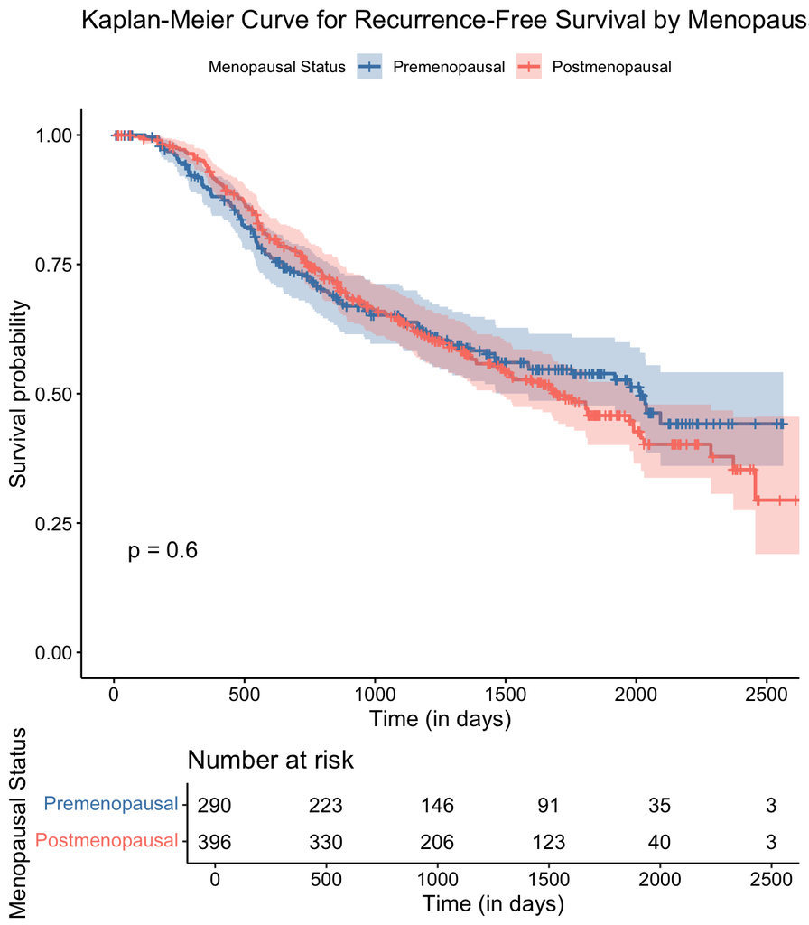

```r
fit_meno <- survfit(surv_obj ~ meno, data = gbsg_clean)
fit_grade <- survfit(surv_obj ~ grade, data = gbsg_clean)
fit_hormon <- survfit(surv_obj ~ hormon, data = gbsg_clean)

ggsurvplot(
  fit_meno,
  data = gbsg_clean,
  # --- Core Plot Customization ---
  conf.int = TRUE,          # Show confidence intervals
  pval = TRUE,              # Show log-rank test p-value
  # --- Aesthetics ---
  palette = c("steelblue", "salmon"),
  legend.labs = c("Premenopausal", "Postmenopausal"),
  legend.title = "Menopausal Status",
  # --- Risk Table Settings ---
  risk.table = TRUE,        # This is the key argument to add the table
  tables.height = 0.2,      # Adjust the height of the table
  # --- Labels ---
  title = "Kaplan-Meier Curve for Recurrence-Free Survival by Menopausal Status",xlab = "Time (in days)")
```

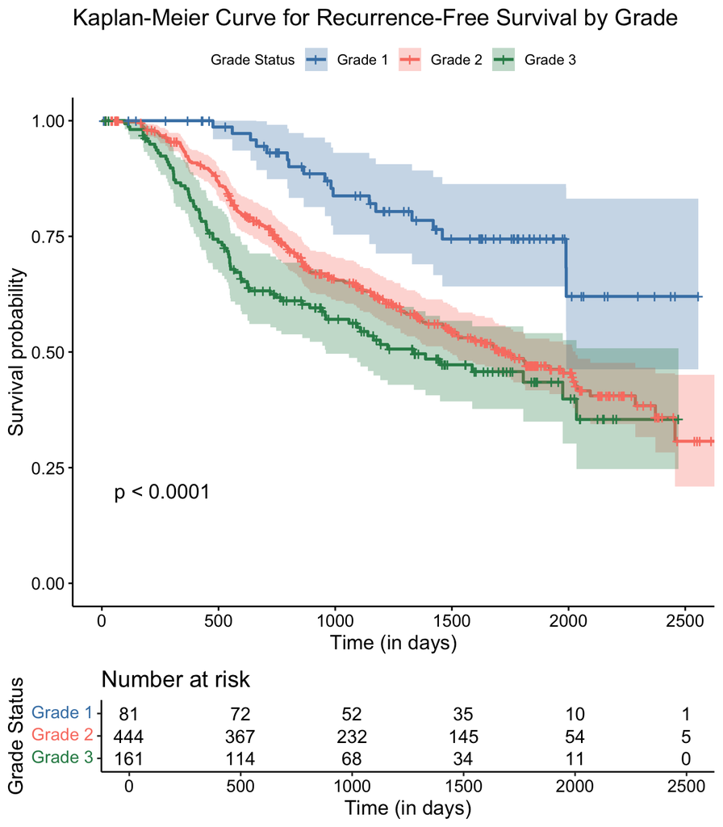

```r
ggsurvplot(
  fit_grade,
  data = gbsg_clean,
  conf.int = TRUE,
  pval = TRUE,
  # --- Aesthetics ---
  palette = c("steelblue", "salmon","seagreen"),
  legend.labs = c("Grade 1", "Grade 2","Grade 3"),
  legend.title = "Grade Status",
  risk.table = TRUE,
  tables.height = 0.2,
  title = "Kaplan-Meier Curve for Recurrence-Free Survival by Grade",xlab = "Time (in days)")
```

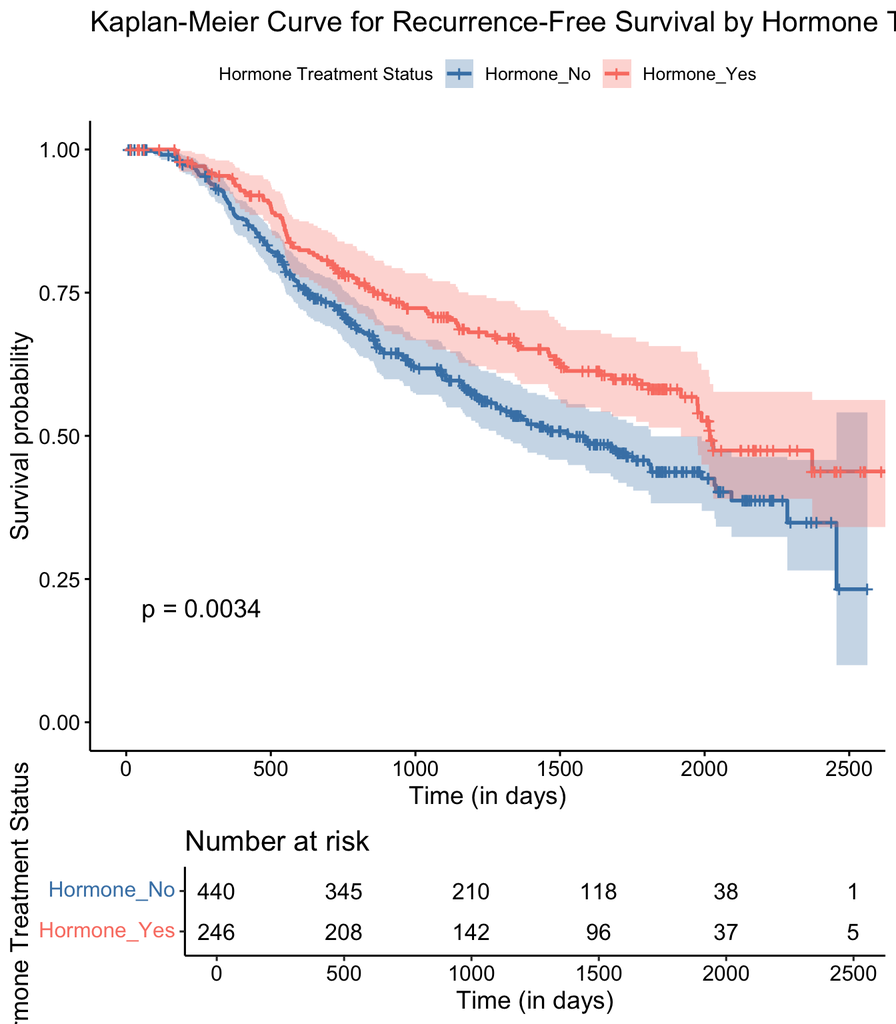

```r
ggsurvplot(
  fit_hormon,
  data = gbsg_clean,
  conf.int = TRUE,
  pval = TRUE,
  # --- Aesthetics ---
  palette = c("steelblue", "salmon"),
  legend.labs = c("Hormone_No", "Hormone_Yes"),
  legend.title = "Hormone Treatment Status",
  risk.table = TRUE,
  tables.height = 0.2,
  title = "Kaplan-Meier Curve for Recurrence-Free Survival by Hormone Treatment",xlab = "Time (in days)")
```

How to Interpret The Hormone Plot:

1. The Axes: The X-axis is time. The Y-axis is the estimated probability of being recurrence-free (survival probability).
2. The Curves: Each colored line represents a group. The lines are “step functions” that drop down each time an event (a recurrence) occurs in that group. A steeper drop means a worse survival outcome. We can see the “Hormone_No” curve is consistently below the “Hormone_Yes” curve, suggesting worse survival.
3. The P-value (Log-Rank Test): The p-value of 0.0034 is statistically significant (p < 0.05). This is the formal hypothesis test confirming that the difference we see between the two curves is unlikely to be due to random chance.
4. The Risk Table: This table at the bottom is crucial. It shows the number of patients still at risk of having an event at specific time points in each group. It gives context to the curve; for example, you can see how many patients are left in the study at the 2000-day mark.